# Attitude Regression

Import ‘attitude’ dataset

```r
data(attitude)
```

plot boxplot for all columns

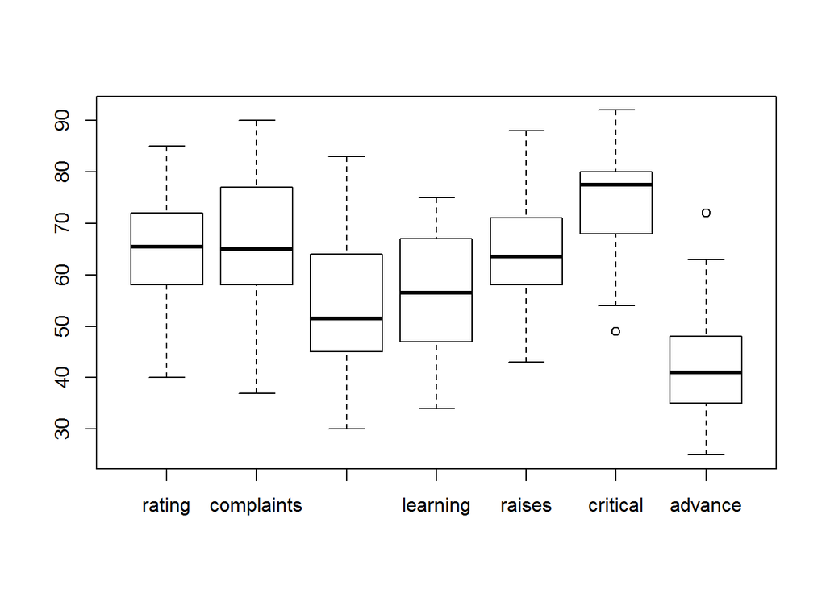

```r
boxplot(attitude)
```

We observe that there are outliers in critical and advance. We take the boxplot stats for the two columns

```r
boxplot.stats(attitude$critical)
```

```
## $stats
## [1] 54.0 68.0 77.5 80.0 92.0
##
## $n
## [1] 30
##
## $conf
## [1] 74.03839 80.96161
##
## $out
## [1] 49
```

The outlier here is the value 49

```r
boxplot.stats(attitude$advance)
```

```
## $stats
## [1] 25 35 41 48 63
##
## $n
## [1] 30
##
## $conf
## [1] 37.24993 44.75007
##
## $out
## [1] 72
```

The outlier is the value 72

In attitude$critical we will identify the position of the value 49.

```r
which(attitude$critical<54)
```

```
## [1] 6
```

The outlier 49 is in the 6th column

In attitude$advance we will identify the position of the value 72.

```r
which(attitude$advance>63)
```

```
## [1] 26
```

The outlier 72 is in the 26th column

We will interpolate these values with the nearby values

```r
attitude$critical[6]<-attitude$critical[7]
attitude$advance[26]<-attitude$advance[27]
```

Now the new dataset is

```r
attitude
```

```
##    rating complaints privileges learning raises critical advance
## 1      43         51         30       39     61       92      45
## 2      63         64         51       54     63       73      47
## 3      71         70         68       69     76       86      48
## 4      61         63         45       47     54       84      35
## 5      81         78         56       66     71       83      47
## 6      43         55         49       44     54       68      34
## 7      58         67         42       56     66       68      35
## 8      71         75         50       55     70       66      41
## 9      72         82         72       67     71       83      31
## 10     67         61         45       47     62       80      41
## 11     64         53         53       58     58       67      34
## 12     67         60         47       39     59       74      41
## 13     69         62         57       42     55       63      25
## 14     68         83         83       45     59       77      35
```

[output cut: 16 more lines]

The new boxplot is

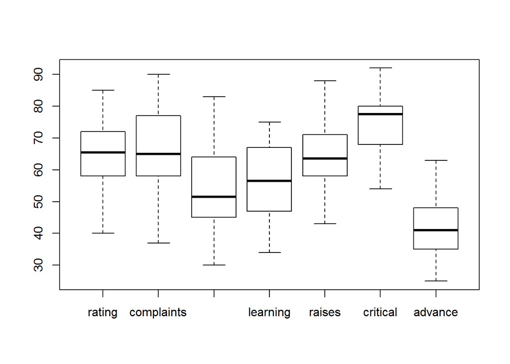

```r
boxplot(attitude)
```

There are no outliers here

Now running regression model on the attitude dataset

```r
model<-lm(rating~complaints+privileges+learning+raises+critical+advance, data = attitude)
```

Low taking the summary of this model

```r
summary(model)
```

```
##
## Call:
## lm(formula = rating ~ complaints + privileges + learning + raises +
##     critical + advance, data = attitude)
##
## Residuals:
##      Min       1Q   Median       3Q      Max
## -12.0499  -5.5559   0.9566   5.9912  11.1604
##
## Coefficients:
##             Estimate Std. Error t value Pr(>|t|)
## (Intercept) 17.66943   13.12158   1.347 0.191232
## complaints   0.64405    0.16049   4.013 0.000545 ***
## privileges  -0.08545    0.13651  -0.626 0.537479
## learning     0.29044    0.18808   1.544 0.136179
## raises       0.05021    0.20917   0.240 0.812439
## critical    -0.06546    0.17517  -0.374 0.712074
## advance     -0.14394    0.20872  -0.690 0.497312
## ---
## Signif. codes:  0 '***' 0.001 '**' 0.01 '*' 0.05 '.' 0.1 ' ' 1
##
## Residual standard error: 7.168 on 23 degrees of freedom
## Multiple R-squared:  0.725,  Adjusted R-squared:  0.6532
## F-statistic:  10.1 on 6 and 23 DF,  p-value: 1.682e-05
```

From the above results we see that only attitude$complaints is significant at 1% interval. We reject the null hypothesis. t-value 4.013>2.807(from t-table, df = 30-7, 99% confidence level)

The F-value is 10.1 which is significant as > 5.65 at 0.1% as per the F stats table. Hence null hypothesis is rejected.

The model explains the data upto 72.5%. Since this has multiple independent variables, we go with the Adjusted R-sq which is 0.6532 i.e 65.32% variation in ‘rating’ can be explained by model.